# Mapping in R

# getting ready

### load packages

if any of these packages are not installed on your system, install them by uncommenting the following section and running it:

```r
# install.packages("data.table")
# install.packages("tigris")
# install.packages("ggplot2")
# install.packages("hrbrthemes")
# install.packages("extrafont")
```

now, load the packages:

```r
library(data.table)
library(tigris)
library(ggplot2)
library(hrbrthemes)
library(extrafont)
```

### setting my data inputs

i like to set my data directory/directories and file(s) as variables at the beginning of my scripts (instead of calling on the full string in my script) so that’s what i’m doing here

```r
data_path   = '/Volumes/GoogleDrive/.shortcut-targets-by-id/1-BTh8T0PMwHDs3KZ9V--KPrNWRUgRxvV/2020_CAEECC_Public_Sector_Underserved/data/processed'
cpuc_file   = 'cpuc_claims_county_2017_2019.csv'
```

# the actual mapping

## loading our data

### read in our county level data

`fread` is the data.table package version of read.csv or read_csv. i like working in data.table because it’s sooo much faster than base R (or tidyverse), but this is a preference thing

```r
cpuc_dt = fread(file.path(data_path, cpuc_file), header = T, colClasses = c('character', rep(NA, 10)))
head(cpuc_dt)
```

| county_fips | county | TotalFirstYearGrosskW | TotalFirstYearGrosskWh | TotalFirstYearGrossTherm | TotalGrossIncentive | TotalGrossMeasureCost | TotalGrossMeasureCost_ER | TotalLifecycleGrosskW | TotalLifecycleGrosskWh | TotalLifecycleGrossTherm |
| --- | --- | --- | --- | --- | --- | --- | --- | --- | --- | --- |
| 001 | Alameda County | 1523.23321 | 12905903.39 | -55316.6149 | 3064973.92 | 11868816.08 | 506782.19 | 14655.3483 | 136426136.6 | -577760.474 |
| 005 | Amador County | 48.72677 | 630359.83 | -4445.0446 | 111048.07 | 1434105.11 | 5995.73 | 546.1184 | 6969586.5 | -47535.941 |
| 007 | Butte County | 38.61104 | 872510.13 | -1126.1593 | 145984.35 | 846437.87 | 76650.04 | 344.2802 | 9598440.7 | -10524.234 |
| 009 | Calaveras County | 12.12810 | 55446.96 | -395.0983 | 16419.90 | 22124.63 | 6614.70 | 138.3706 | 600834.8 | -4670.729 |
| 011 | Colusa County | 18.54985 | 150363.09 | -498.7718 | 26848.97 | 76808.68 | 45531.12 | 203.2351 | 1745071.4 | -5700.959 |
| 013 | Contra Costa County | 1084.06255 | 9723710.97 | -33593.8925 | 2081127.24 | 7158809.13 | 777626.95 | 10047.6040 | 94603718.1 | -363493.395 |

also, i specify the first column as a character type because i know that’s the column that’s the county’s FIPS code. if not specified, `fread` will detect it as a numeric type and get rid of the leading zeroes in the column

## using the tigris package to get maps of TIGER/Line dataset

we just need county maps for now, but tigris does offer more functionality. read about the package [here](https://github.com/walkerke/tigris).

```r
ca_counties = counties(state = 'CA')
head(ca_counties)
```

```
Simple feature collection with 6 features and 17 fields
geometry type:  MULTIPOLYGON
dimension:      XY
bbox:           xmin: -121.8626 ymin: 32.75004 xmax: -117.6464 ymax: 39.77688
epsg (SRID):    4269
proj4string:    +proj=longlat +ellps=GRS80 +towgs84=0,0,0,0,0,0,0 +no_defs
    STATEFP COUNTYFP COUNTYNS GEOID          NAME             NAMELSAD LSAD CLASSFP MTFCC CSAFP CBSAFP METDIVFP FUNCSTAT       ALAND     AWATER    INTPTLAT
9        06      091 00277310 06091        Sierra        Sierra County   06      H1 G4020  <NA>   <NA>     <NA>        A  2468694583   23299110 +39.5769252
326      06      067 00277298 06067    Sacramento    Sacramento County   06      H1 G4020   472  40900     <NA>        A  2499983887   75425434 +38.4500161
330      06      083 00277306 06083 Santa Barbara Santa Barbara County   06      H1 G4020  <NA>  42200     <NA>        A  7084063392 2729751706 +34.5370572
347      06      009 01675885 06009     Calaveras     Calaveras County   06      H1 G4020  <NA>   <NA>     <NA>        A  2641784992   43841871 +38.1838996
395      06      111 00277320 06111       Ventura       Ventura County   06      H1 G4020   348  37100     <NA>        A  4771987962  947345370 +34.3587415
398      06      037 00277283 06037   Los Angeles   Los Angeles County   06      H1 G4020   348  31080    31084        A 10511861492 1793485467 +34.1963983
        INTPTLON                       geometry
9   -120.5219926 MULTIPOLYGON (((-120.6556 3...
326 -121.3404408 MULTIPOLYGON (((-121.1886 3...
330 -120.0399729 MULTIPOLYGON (((-120.7343 3...
347 -120.5614415 MULTIPOLYGON (((-120.6309 3...
395 -119.1331432 MULTIPOLYGON (((-119.3292 3...
398 -118.2618616 MULTIPOLYGON (((-118.7034 3...
```

what does that `ca_counties` object look like if we just mapped it as is? the `geom_sf` file in the ggplot2 package creates maps of shapefiles

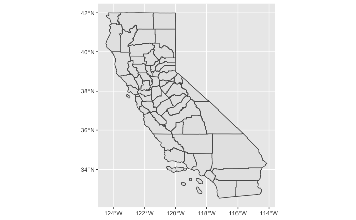

```r
ggplot(ca_counties)  +
  geom_sf()
```

## merging data

now that we have one object that’s kind of like a shapefile (`ca_counties`) and we have our own data.table of variables we would actually want to plot (`cpuc_dt`), we can merge the two objects using the FIPS code column as the common key

```r
merge_dt = merge(ca_counties, cpuc_dt,
                 by.x = 'COUNTYFP',
                 by.y = 'county_fips')
head(merge_dt)
```

```
Simple feature collection with 6 features and 27 fields
geometry type:  MULTIPOLYGON
dimension:      XY
bbox:           xmin: -122.7851 ymin: 37.45419 xmax: -120.02 ymax: 40.15202
epsg (SRID):    4269
proj4string:    +proj=longlat +ellps=GRS80 +towgs84=0,0,0,0,0,0,0 +no_defs
  COUNTYFP STATEFP COUNTYNS GEOID         NAME            NAMELSAD LSAD CLASSFP MTFCC CSAFP CBSAFP METDIVFP FUNCSTAT      ALAND    AWATER    INTPTLAT     INTPTLON
1      001      06 01675839 06001      Alameda      Alameda County   06      H1 G4020   488  41860    36084        A 1909614756 216907015 +37.6471385 -121.9124880
2      005      06 01675841 06005       Amador       Amador County   06      H1 G4020  <NA>   <NA>     <NA>        A 1539933596  29470567 +38.4435501 -120.6538563
3      007      06 01675842 06007        Butte        Butte County   06      H1 G4020  <NA>  17020     <NA>        A 4238488156 105261063 +39.6659588 -121.6019188
4      009      06 01675885 06009    Calaveras    Calaveras County   06      H1 G4020  <NA>   <NA>     <NA>        A 2641784992  43841871 +38.1838996 -120.5614415
5      011      06 01675902 06011       Colusa       Colusa County   06      H1 G4020  <NA>   <NA>     <NA>        A 2980332742  14608887 +39.1777385 -122.2375629
6      013      06 01675903 06013 Contra Costa Contra Costa County   06      H1 G4020   488  41860    36084        A 1857229826 225285866 +37.9194790 -121.9515431
               county TotalFirstYearGrosskW TotalFirstYearGrosskWh TotalFirstYearGrossTherm TotalGrossIncentive TotalGrossMeasureCost TotalGrossMeasureCost_ER
1      Alameda County            1523.23321            12905903.39              -55316.6149          3064973.92           11868816.08                506782.19
2       Amador County              48.72677              630359.83               -4445.0446           111048.07            1434105.11                  5995.73
3        Butte County              38.61104              872510.13               -1126.1593           145984.35             846437.87                 76650.04
4    Calaveras County              12.12810               55446.96                -395.0983            16419.90              22124.63                  6614.70
5       Colusa County              18.54985              150363.09                -498.7718            26848.97              76808.68                 45531.12
6 Contra Costa County            1084.06255             9723710.97              -33593.8925          2081127.24            7158809.13                777626.95
  TotalLifecycleGrosskW TotalLifecycleGrosskWh TotalLifecycleGrossTherm                       geometry
1            14655.3483            136426136.6              -577760.474 MULTIPOLYGON (((-122.2809 3...
2              546.1184              6969586.5               -47535.941 MULTIPOLYGON (((-121.0273 3...
3              344.2802              9598440.7               -10524.234 MULTIPOLYGON (((-121.8565 3...
4              138.3706               600834.8                -4670.729 MULTIPOLYGON (((-120.6309 3...
5              203.2351              1745071.4                -5700.959 MULTIPOLYGON (((-122.0802 3...
6            10047.6040             94603718.1              -363493.395 MULTIPOLYGON (((-122.2676 3...
```

## creating choropleth maps of our data

let’s map total gross measure costs as an example

### simple choropleth map

without making any stylistic changes, here’s what a map using TotalGrossMeasureCost as the choropleth variable looks like:

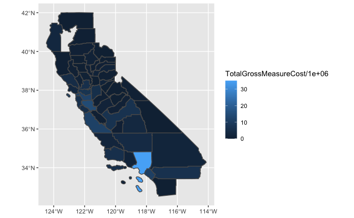

```r
ggplot(merge_dt, aes(fill = TotalGrossMeasureCost/1e6)) +
  geom_sf()
```

that’s the basis of it! visually i don’t like how that looks so let’s make some aesthetic changes

### map with some aesthetic changes

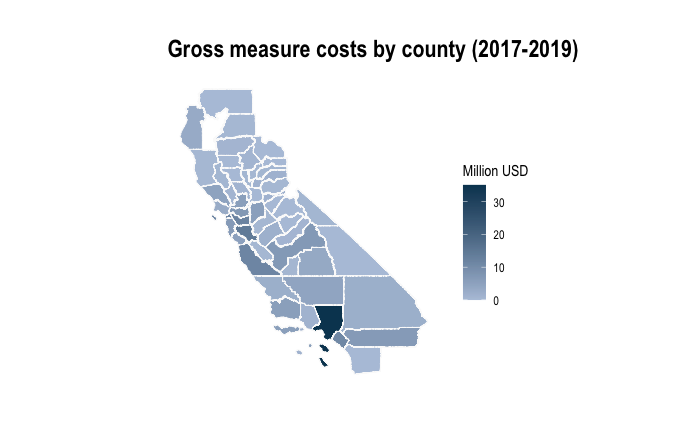

```r
map_costs = ggplot(merge_dt, aes(fill = TotalGrossMeasureCost/1e6)) +
  geom_sf(color = '#fafafa', lwd = 0.3) +
  labs(title = 'Gross measure costs by county (2017-2019)',
       x = NULL,
       y = NULL,
       fill = 'Million USD') +
  guides(color = 'none') +
  scale_fill_gradient(low = '#b5c5dc', high = '#074360') +
  theme_ipsum(grid = FALSE) +
  theme(axis.title = element_blank(),
        axis.ticks = element_blank(),
        axis.text.x = element_blank(),
        axis.text.y = element_blank(),
        axis.line.x = element_blank(),
        axis.line.y = element_blank())
map_costs
```

a bit better, but it seems like LA county is vastly different from the rest, right? that’s because LA county’s total gross measure costs is significantly higher than all other counties, so it’s skewing the visualization.

### distribution of gross measure costs

we can verify by plotting some density plots or histograms

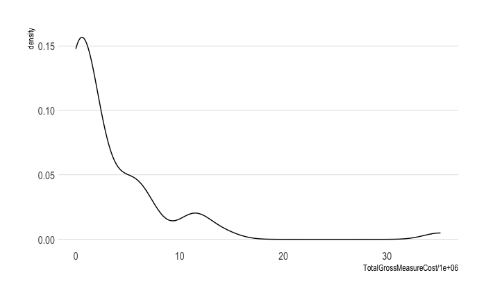

```r
ggplot(cpuc_dt, aes(x = TotalGrossMeasureCost/1e6)) +
  geom_density() +
  theme_ipsum(grid = 'Y')
```

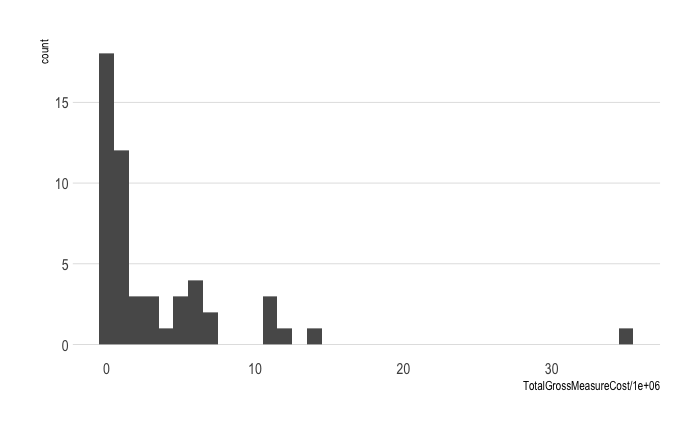

```r
ggplot(cpuc_dt, aes(x = TotalGrossMeasureCost/1e6)) +
  geom_histogram(binwidth = 1) +
  theme_ipsum(grid = 'Y')
```

so yeah, LA county is the only county in the 30 million+ USD range (or even 20 million USD+). a better map might use different breaks, but i’m too lazy to do that right now :)

## saving map

### saving as pdf

my preference is to save figures as PDFs – they’re vectorized, don’t become blurry if you resize, and the file sizes are much smaller. the tricky part with PDFs is you should embed fonts onto the pdf so that people who may not have the font on their computer can still the text when they open the pdf

```r
ggsave(map_costs,
       filename = here::here('figures', 'map-gross-measure-costs-by-county.pdf'),
       width = 8,
       height = 6.25)

embed_fonts(here::here('figures', 'map-gross-measure-costs-by-county.pdf'),
            outfile = here::here('figures', 'map-gross-measure-costs-by-county.pdf'))
```

### saving as png

png (or jpg and other similar file types) are still the standard, and google docs doesn’t let you put in pdf images so we should also save pngs sometimes

```r
ggsave(map_costs,
       filename = here::here('figures', 'map-gross-measure-costs-by-county.png'),
       width = 8,
       height = 6.25,
       dpi = 600)
```